# Your Dementia Risk Report and Personalized Program Strategy

This report summarizes the results of the data captured during your visit. Included in this report is a list of treatable health conditions potentially contributing to dementia risk as well as a Personalized Program Strategy that will help improve overall brain health and wellness. These results are intended to help you better understand you own health and guide potential lifestyle modifications to optimize your well-being.

## Treatable Health Conditions Contributing to Dementia Risk

Some treatable health conditions may be contributing to your risk for dementia. Please consider speaking to your healthcare professional on how to lifestyle modifications or medication may treat the following:

Treatable Health Conditions

- Smoking
- High Blood Pressure

## Personalized Program Strategy

#### You are doing great in these areas, keep it up!

Mental Wellbeing

#### Focus on these areas over the next six months to reduce your risk of dementia:

Cognitive Engagement

Select at least one hour weekly of cognitive engagement programming.

Social Connections

Social Connections will be incorporated into all other programming.

Brain-Healthy Eating

Take the two foundational courses, and then at least three additional one-session classes.

Physical Activity

Work with the fitness coordinator to choose the right kinds of programs. Gradually work up to 150 minutes of moderate-to-vigorous aerobic physical activity a week, plus strength training at least two days a week.

## Your Scores

### Cognitive Engagement

[figure not shown]

Engaging in arts and crafts, performing arts, and lecture series improves cognition.

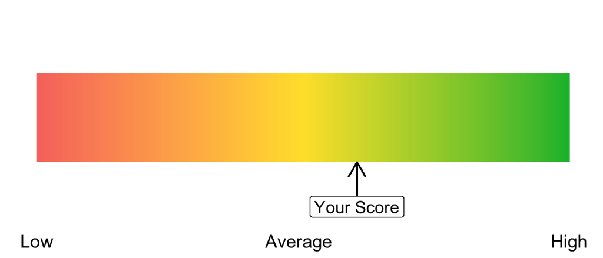

### Social Engagement

[figure not shown]

People who are socially connected are more likely to maintain their cognition with age.

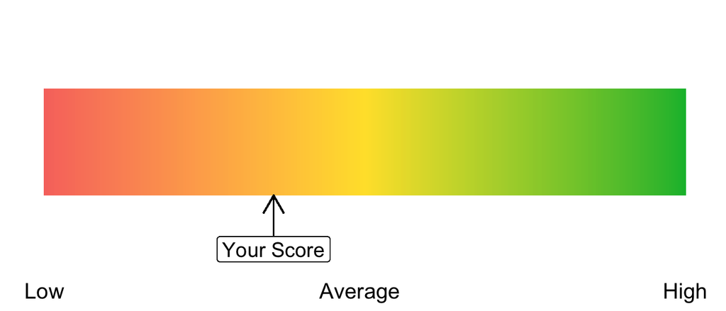

### Diet

[figure not shown]

Healthy eating is associated with better cognitive function and lower dementia risk.

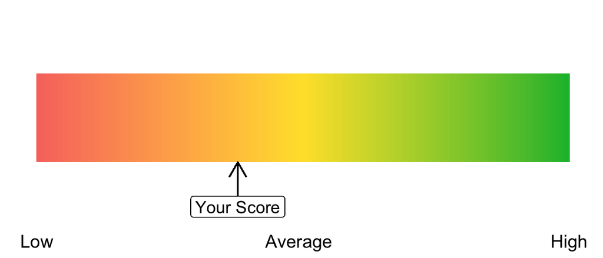

### Mental Wellbeing

Practicing regular meditation, yoga, etc. can benefit cognition and brain health.

### Depression

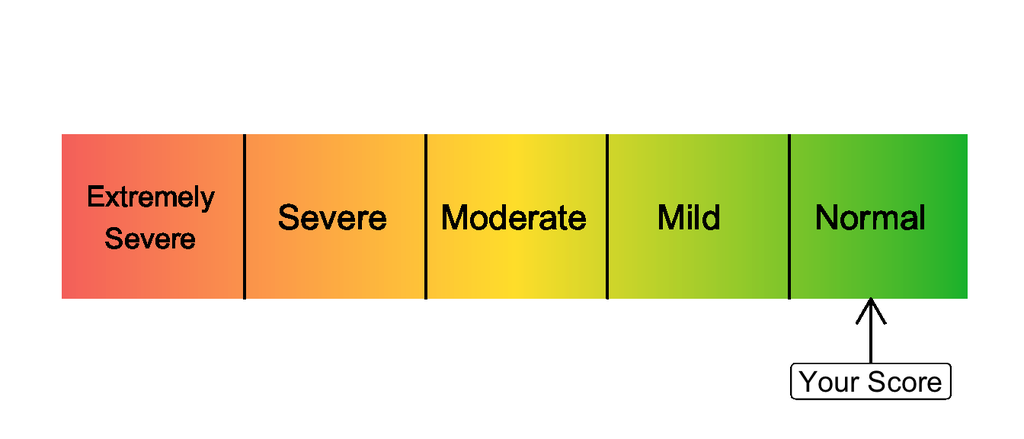

### Anxiety

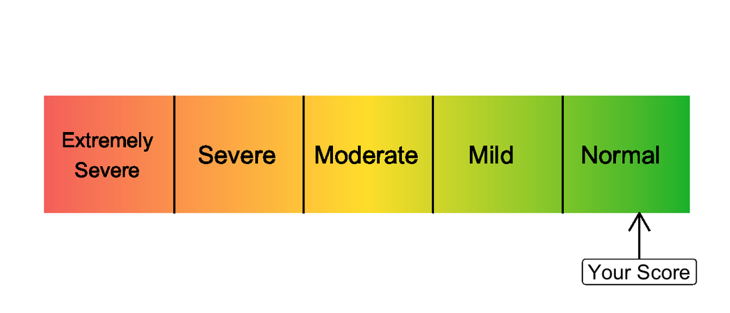

### Distress

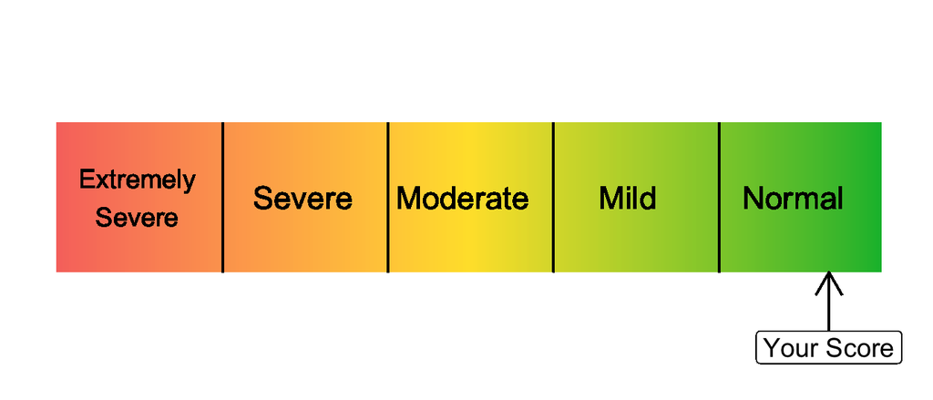

### Perceived Stress

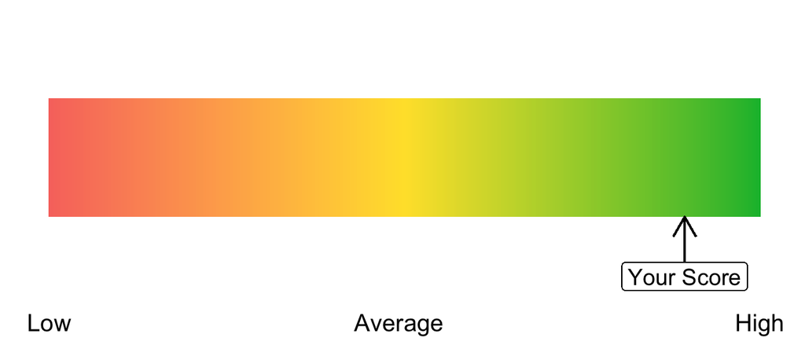

### Physical Activity

[figure not shown]

Exercise improves cognition, mood, and brain health. It even produces new neurons!

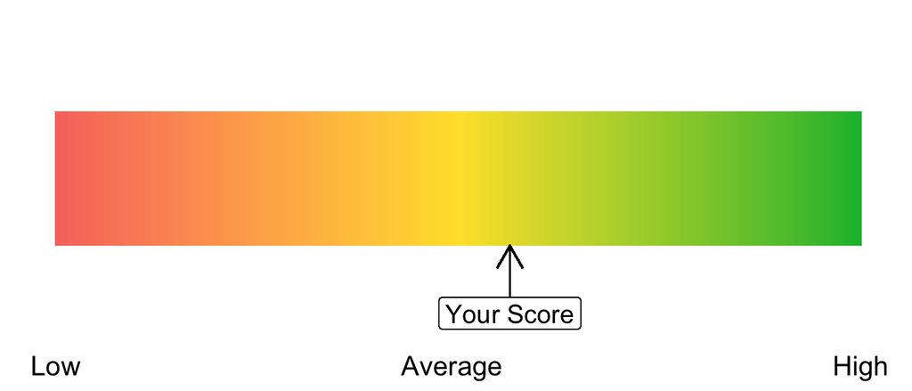